# DATA 607 Final Project

Seung Min Song

2022-12-04

GitHub: https://github.com/seung-m1nsong/607/tree/main/Final%20Project  
Rpub: https://rpubs.com/seungm1nsong/978730

[output not shown]

## Part 2 - Data

I downloaded the csv data table from the link below:  
https://www.kaggle.com/datasets/yashpaloswal/ann-car-sales-price-prediction

### CSV

View GitHub CSV file to RStudio

```r
dfdata <- data.table::fread( "https://raw.githubusercontent.com/seung-m1nsong/607/main/Final%20Project/car_purchasing.csv",
               select=c("customer_name",    "customer_email",   "country",  "gender",   "age",  "annual_Salary",    "credit_card_debt", "net_worth",    "car_purchase_amount"))
```

```r
dfdata %>% head(n=10)
```

```
##       customer_name                                             customer_email
##  1:   Martina Avila          cubilia.Curae.Phasellus@quisaccumsanconvallis.edu
##  2:   Harlan Barnes                                        eu.dolor@diam.co.uk
##  3: Naomi Rodriquez vulputate.mauris.sagittis@ametconsectetueradipiscing.co.uk
##  4: Jade Cunningham                                    malesuada@dignissim.com
##  5:    Cedric Leach             felis.ullamcorper.viverra@egetmollislectus.net
##  6:    Carla Hester                                         mi@Aliquamerat.edu
##  7:  Griffin Rivera                                          vehicula@at.co.uk
##  8:      Orli Casey            nunc.est.mollis@Suspendissetristiqueneque.co.uk
##  9:    Marny Obrien                                Phasellus@sedsemegestas.org
## 10:   Rhonda Chavez                                            nec@nuncest.com
##            country gender age annual_Salary credit_card_debt net_worth
##  1:       Bulgaria      0  42      62812.09         11609.38  238961.2
##  2:         Belize      0  41      66646.89          9572.96  530973.9
##  3:        Algeria      1  43      53798.55         11160.36  638467.2
```

[output cut: 18 more lines]

```r
colnames(dfdata)
```

```
## [1] "customer_name"       "customer_email"      "country"
## [4] "gender"              "age"                 "annual_Salary"
## [7] "credit_card_debt"    "net_worth"           "car_purchase_amount"
```

### Data Transformtion, Cleanup and Preparation:

change gender value **1** and **0** to **M** and **F**.

```r
dfdata <- transform(dfdata, gender = ifelse(gender == '0', 'F', 'M'))
head(dfdata)
```

```
##      customer_name                                             customer_email
## 1:   Martina Avila          cubilia.Curae.Phasellus@quisaccumsanconvallis.edu
## 2:   Harlan Barnes                                        eu.dolor@diam.co.uk
## 3: Naomi Rodriquez vulputate.mauris.sagittis@ametconsectetueradipiscing.co.uk
## 4: Jade Cunningham                                    malesuada@dignissim.com
## 5:    Cedric Leach             felis.ullamcorper.viverra@egetmollislectus.net
## 6:    Carla Hester                                         mi@Aliquamerat.edu
##         country gender age annual_Salary credit_card_debt net_worth
## 1:     Bulgaria      F  42      62812.09         11609.38  238961.2
## 2:       Belize      F  41      66646.89          9572.96  530973.9
## 3:      Algeria      M  43      53798.55         11160.36  638467.2
## 4: Cook Islands      M  58      79370.04         14426.16  548599.1
## 5:       Brazil      M  57      59729.15          5358.71  560304.1
## 6:      Liberia      M  57      68499.85         14179.47  428485.4
##    car_purchase_amount
## 1:            35321.46
## 2:            45115.53
## 3:            42925.71
## 4:            67422.36
## 5:            55915.46
## 6:            56612.00
```

Convert **gender** and **country** data type; double to Character.

```r
dfdata %>%
  mutate_at(c('gender', 'country'), as.character)
```

```
##        customer_name                                             customer_email
##   1:   Martina Avila          cubilia.Curae.Phasellus@quisaccumsanconvallis.edu
##   2:   Harlan Barnes                                        eu.dolor@diam.co.uk
##   3: Naomi Rodriquez vulputate.mauris.sagittis@ametconsectetueradipiscing.co.uk
##   4: Jade Cunningham                                    malesuada@dignissim.com
##   5:    Cedric Leach             felis.ullamcorper.viverra@egetmollislectus.net
##  ---
## 496:          Walter                                        ligula@Cumsociis.ca
## 497:           Vanna                         Cum.sociis.natoque@Sedmolestie.edu
## 498:           Pearl                              penatibus.et@massanonante.com
## 499:            Nell                          Quisque.varius@arcuVivamussit.net
## 500:           Marla                                  Camaron.marla@hotmail.com
##           country gender age annual_Salary credit_card_debt net_worth
##   1:     Bulgaria      F  42      62812.09         11609.38  238961.2
##   2:       Belize      F  41      66646.89          9572.96  530973.9
```

[output cut: 21 more lines]

create new column with auto increment named, **customerid**. I will use this **custoemrid** to connect all my sql tables.

```r
dfdata1 <- cbind(customerid = 1:nrow(dfdata), dfdata)
head(dfdata1)
```

```
##    customerid   customer_name
## 1:          1   Martina Avila
## 2:          2   Harlan Barnes
## 3:          3 Naomi Rodriquez
## 4:          4 Jade Cunningham
## 5:          5    Cedric Leach
## 6:          6    Carla Hester
##                                                customer_email      country
## 1:          cubilia.Curae.Phasellus@quisaccumsanconvallis.edu     Bulgaria
## 2:                                        eu.dolor@diam.co.uk       Belize
## 3: vulputate.mauris.sagittis@ametconsectetueradipiscing.co.uk      Algeria
## 4:                                    malesuada@dignissim.com Cook Islands
## 5:             felis.ullamcorper.viverra@egetmollislectus.net       Brazil
## 6:                                         mi@Aliquamerat.edu      Liberia
##    gender age annual_Salary credit_card_debt net_worth car_purchase_amount
## 1:      F  42      62812.09         11609.38  238961.2            35321.46
## 2:      F  41      66646.89          9572.96  530973.9            45115.53
## 3:      M  43      53798.55         11160.36  638467.2            42925.71
## 4:      M  58      79370.04         14426.16  548599.1            67422.36
## 5:      M  57      59729.15          5358.71  560304.1            55915.46
## 6:      M  57      68499.85         14179.47  428485.4            56612.00
```

### MySQL

We will start with creating a data frame to store the data.

```r
dfdata_customer <- dfdata1 %>%
 select(c(customerid,customer_name, customer_email, country, gender, age))
dfdata_customer
```

```
##      customerid   customer_name
##   1:          1   Martina Avila
##   2:          2   Harlan Barnes
##   3:          3 Naomi Rodriquez
##   4:          4 Jade Cunningham
##   5:          5    Cedric Leach
##  ---
## 496:        496          Walter
## 497:        497           Vanna
## 498:        498           Pearl
## 499:        499            Nell
## 500:        500           Marla
##                                                  customer_email      country
##   1:          cubilia.Curae.Phasellus@quisaccumsanconvallis.edu     Bulgaria
##   2:                                        eu.dolor@diam.co.uk       Belize
```

[output cut: 21 more lines]

```r
dfdata_salary <- dfdata1 %>%
  select(c(customerid, annual_Salary))
dfdata_salary
```

```
##      customerid annual_Salary
##   1:          1      62812.09
##   2:          2      66646.89
##   3:          3      53798.55
##   4:          4      79370.04
##   5:          5      59729.15
##  ---
## 496:        496      71942.40
## 497:        497      56039.50
## 498:        498      68888.78
## 499:        499      49811.99
## 500:        500      61370.68
```

```r
dfdata_debt <-  dfdata1 %>%
  select(c(customerid, credit_card_debt))
dfdata_debt
```

```
##      customerid credit_card_debt
##   1:          1         11609.38
##   2:          2          9572.96
##   3:          3         11160.36
##   4:          4         14426.16
##   5:          5          5358.71
##  ---
## 496:        496          6995.90
## 497:        497         12301.46
## 498:        498         10611.61
## 499:        499         14013.03
## 500:        500          9391.34
```

```r
dfdata_networth <-  dfdata1 %>%
  select(c(customerid, net_worth))
dfdata_networth
```

```
##      customerid net_worth
##   1:          1  238961.2
##   2:          2  530973.9
##   3:          3  638467.2
##   4:          4  548599.1
##   5:          5  560304.1
##  ---
## 496:        496  541670.1
## 497:        497  360419.1
## 498:        498  764531.3
## 499:        499  337826.6
## 500:        500  462946.5
```

```r
dfdata_carpurchaseamount <-  dfdata1 %>%
  select(c(customerid, car_purchase_amount))
dfdata_carpurchaseamount
```

```
##      customerid car_purchase_amount
##   1:          1            35321.46
##   2:          2            45115.53
##   3:          3            42925.71
##   4:          4            67422.36
##   5:          5            55915.46
##  ---
## 496:        496            48901.44
## 497:        497            31491.41
## 498:        498            64147.29
## 499:        499            45442.15
## 500:        500            45107.23
```

Please visit https://github.com/seung-m1nsong/607 **Final Project** to view my MYSQL query.

```r
# Connect with my Local MySQl Database.
con <- DBI::dbConnect(
  RMySQL::MySQL(),
  user="root",
  password="",
  host="localhost",
  dbname="carprice"
)
```

Using dbWriteTable() function, I will send my R data frames to SQL tables.

```r
table_names <- c('customer', 'salary', 'debt','networth', 'carpurchaseamount')
df <- list(dfdata_customer, dfdata_salary, dfdata_debt, dfdata_networth, dfdata_carpurchaseamount)
lapply(seq_along(table_names), function(i) dbWriteTable(con, table_names[[i]], df[[i]], row.names=FALSE, append=TRUE))
```

```
## [[1]]
## [1] TRUE
##
## [[2]]
## [1] TRUE
##
## [[3]]
## [1] TRUE
##
## [[4]]
## [1] TRUE
##
## [[5]]
## [1] TRUE
```

### Histogram

Select only columns that are relevant for our purpose. I am not interested in any personal information for the analysis. Therefore I removed **customer_name** and **customer_email** from my dataframe.

```r
dfdata <- subset (dfdata, select = -c(customer_name,customer_email))
head(dfdata)
```

```
##         country gender age annual_Salary credit_card_debt net_worth
## 1:     Bulgaria      F  42      62812.09         11609.38  238961.2
## 2:       Belize      F  41      66646.89          9572.96  530973.9
## 3:      Algeria      M  43      53798.55         11160.36  638467.2
## 4: Cook Islands      M  58      79370.04         14426.16  548599.1
## 5:       Brazil      M  57      59729.15          5358.71  560304.1
## 6:      Liberia      M  57      68499.85         14179.47  428485.4
##    car_purchase_amount
## 1:            35321.46
## 2:            45115.53
## 3:            42925.71
## 4:            67422.36
## 5:            55915.46
## 6:            56612.00
```

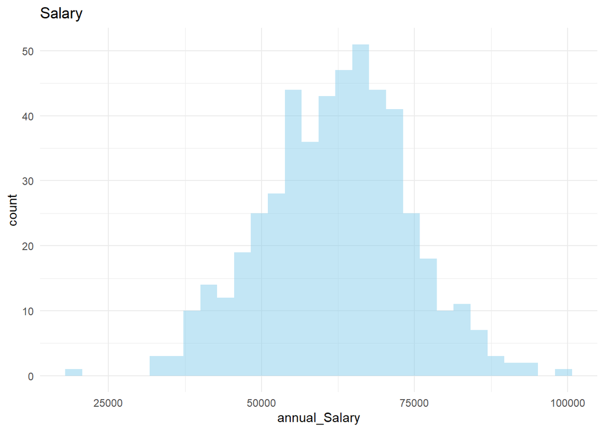

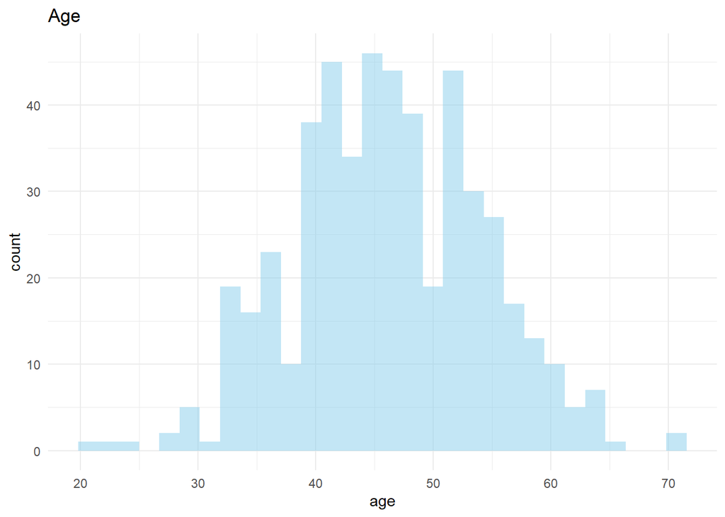

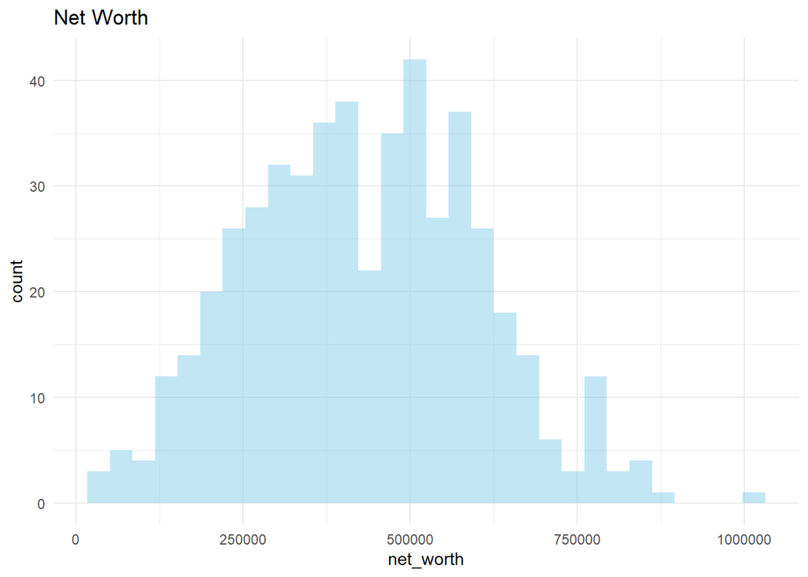

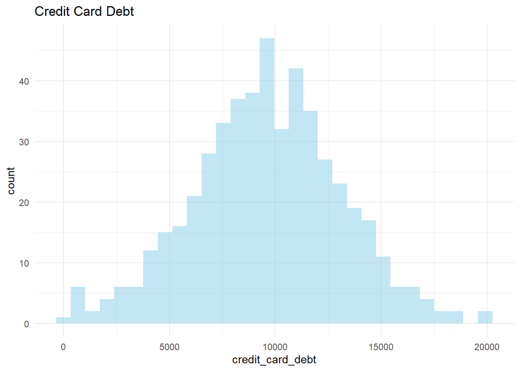

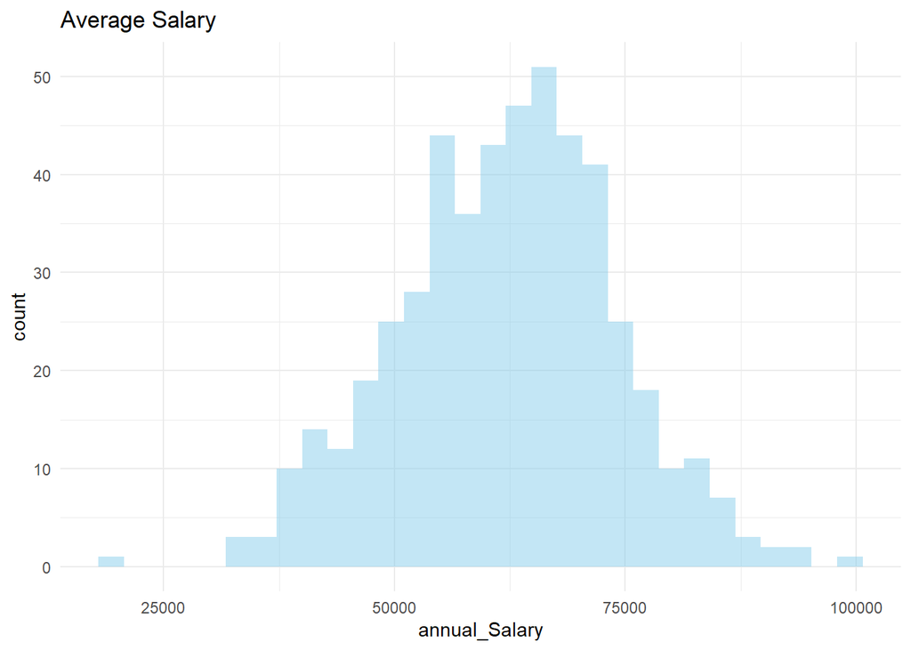

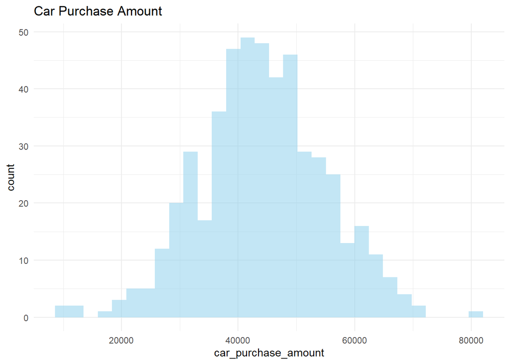

## Part 3 - Exploratory data analysis

```r
summary(dfdata$age)
```

```
##    Min. 1st Qu.  Median    Mean 3rd Qu.    Max.
##   20.00   41.00   46.00   46.22   52.00   70.00
```

```r
summary(dfdata$annual_Salary)
```

```
##    Min. 1st Qu.  Median    Mean 3rd Qu.    Max.
##   20000   54392   62916   62127   70118  100000
```

```r
summary(dfdata$credit_card_debt)
```

```
##    Min. 1st Qu.  Median    Mean 3rd Qu.    Max.
##     100    7398    9655    9608   11799   20000
```

```r
summary(dfdata$net_worth)
```

```
##    Min. 1st Qu.  Median    Mean 3rd Qu.    Max.
##   20000  299824  426750  431476  557325 1000000
```

```r
summary(dfdata$car_purchase_amount)
```

```
##    Min. 1st Qu.  Median    Mean 3rd Qu.    Max.
##    9000   37630   43998   44210   51255   80000
```

### Gender

```
## # A tibble: 2 x 2
##   gender car_purchase_amount
##   <chr>                <dbl>
## 1 F                   44933.
## 2 M                   43504.
```

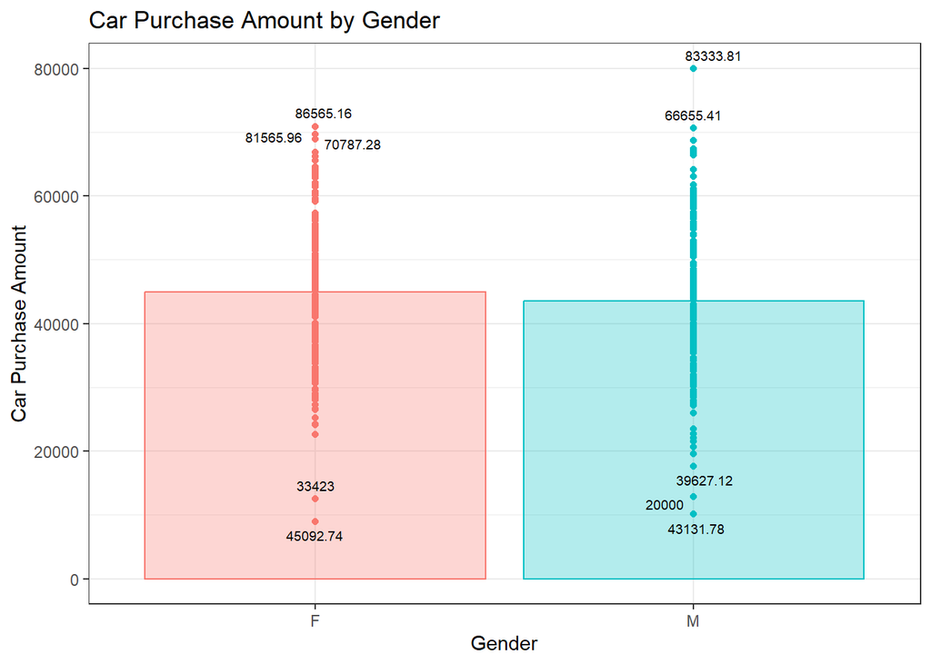

### Age

Total paid to a car vs age separated with genders. Car purchase amount increases when age increases.

```
## # A tibble: 76 x 6
## # Groups:   age [43]
##      age gender annual_Salary credit_card_debt net_worth car_purchase_amount
##    <int> <chr>          <dbl>            <dbl>     <dbl>               <dbl>
##  1    20 M             70467.             100    494607.              28645.
##  2    22 M             43132.           10917.   326743.              10092.
##  3    25 F             45093.           11380.   158758.               9000
##  4    27 F             55370.           10889.   606851.              29671.
##  5    28 F             82843.           13102.   315775.              37162.
##  6    29 M             62303.            8562.   444786.              30088.
##  7    30 M             66763.            6484.   426726.              33134.
##  8    31 F             41362.           10756.   615720.              25253.
##  9    32 F             68672.            9266.   453192.              36479.
## 10    32 M             44926.           12158.   572525.              26529.
## # ... with 66 more rows
```

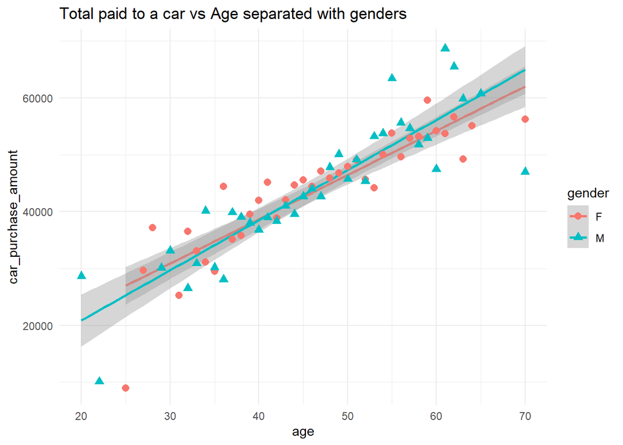

Creating a data frame which will store **age**.

```r
p <-  as.data.frame(71)
colnames(p) <- "age"
```

Calculating the correlation between **age** and **car_purchase_amount**.

```r
cor(dfdata$car_purchase_amount,dfdata$age)
```

```
## [1] 0.6332726
```

It means for a change in one unit in **age** will bring 853.83 units to change in **car_purchase_amount**.

```r
model1 <- lm(car_purchase_amount ~ age, data = dfdata)
summary(model1)
```

```
##
## Call:
## lm(formula = car_purchase_amount ~ age, data = dfdata)
##
## Residuals:
##      Min       1Q   Median       3Q      Max
## -23239.3  -5721.9    277.7   5658.4  28297.0
##
## Coefficients:
##             Estimate Std. Error t value Pr(>|t|)
## (Intercept)  4742.55    2193.38   2.162   0.0311 *
## age           853.83      46.76  18.260   <2e-16 ***
## ---
## Signif. codes:  0 '***' 0.001 '**' 0.01 '*' 0.05 '.' 0.1 ' ' 1
##
## Residual standard error: 8346 on 498 degrees of freedom
## Multiple R-squared:  0.401,  Adjusted R-squared:  0.3998
## F-statistic: 333.4 on 1 and 498 DF,  p-value: < 2.2e-16
```

I can predict at the age of 71 the **car_purchase_amount** will be $65364.19.

```r
predict(model1, newdata = p)
```

```
##        1
## 65364.19
```

### Country

```
## # A tibble: 211 x 3
##    country        avg_annual_Salary avg_car_purchase_amount
##    <chr>                      <dbl>                   <dbl>
##  1 ?land Islands             72971.                  51013.
##  2 Afghanistan               75937.                  56018.
##  3 Algeria                   66513.                  47752.
##  4 American Samoa            38454.                  24222
##  5 Andorra                   59894.                  39240.
##  6 Angola                    62074.                  44498
##  7 Anguilla                  70350.                  48189.
##  8 Antarctica                66551.                  47059.
##  9 Argentina                 68326.                  48664.
## 10 Armenia                   67465.                  45037.
## # ... with 201 more rows
```

Use ggplot() + geom_point to compare **car_purchase_amount** by **country**. The **geom_abline** displays the red line in the graph. Any country name above the red line indicates annual salary is higher than the purchased car price and the country name below the red line indicates annual salary is lower than the purchased car price. Most of countries purchased a car below their annual salary.

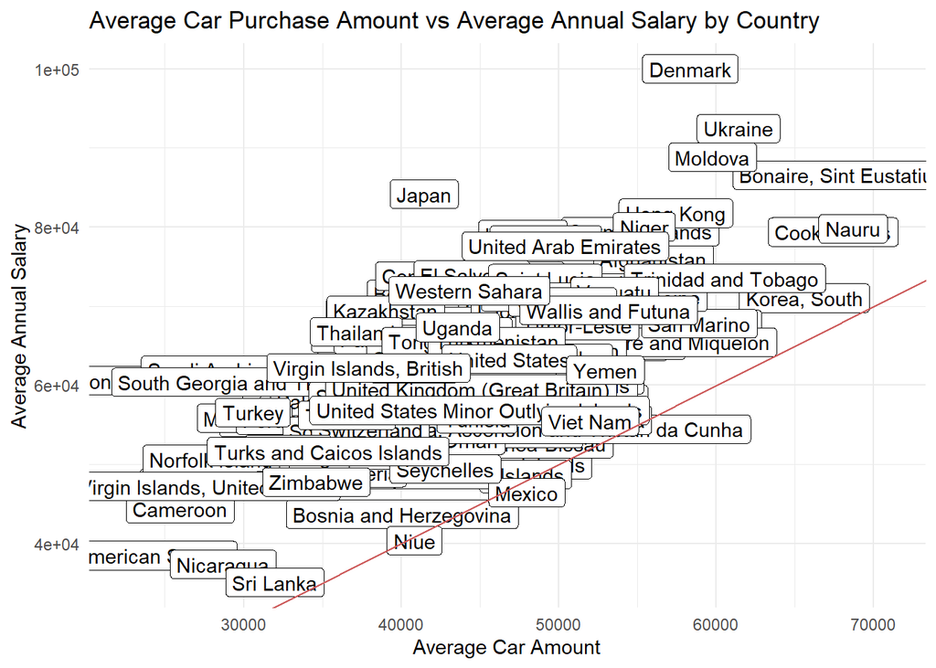

### Salary

Comparatively, women bought more expensive cars than men. Probably because the more expensive the car, the safer it is. Also, as seen here, the higher the annual salary, the higher the car purchase price.

```
## # A tibble: 500 x 7
## # Groups:   gender [2]
##    gender annual_Salary country   age credit_card_debt net_worth car_purchase_~1
##    <chr>          <dbl>   <dbl> <dbl>            <dbl>     <dbl>           <dbl>
##  1 F             32698.      NA    55           10858.   218809.          28464.
##  2 F             33423       NA    35            8571.   211169.          12537.
##  3 F             34155.      NA    51            5316.   216355.          26499.
##  4 F             37336.      NA    44           10218.   430907.          28700.
##  5 F             38214.      NA    52           11493.   579059.          39893.
##  6 F             38284.      NA    42           15468.   587011.          31697
##  7 F             38454.      NA    42           15283.   320834.          24222
##  8 F             38779.      NA    61           12759.   581498.          47936.
##  9 F             39488.      NA    56           10992.   363561.          37714.
## 10 F             40388.      NA    62            5761.   622570.          50540.
## # ... with 490 more rows, and abbreviated variable name 1: car_purchase_amount
```

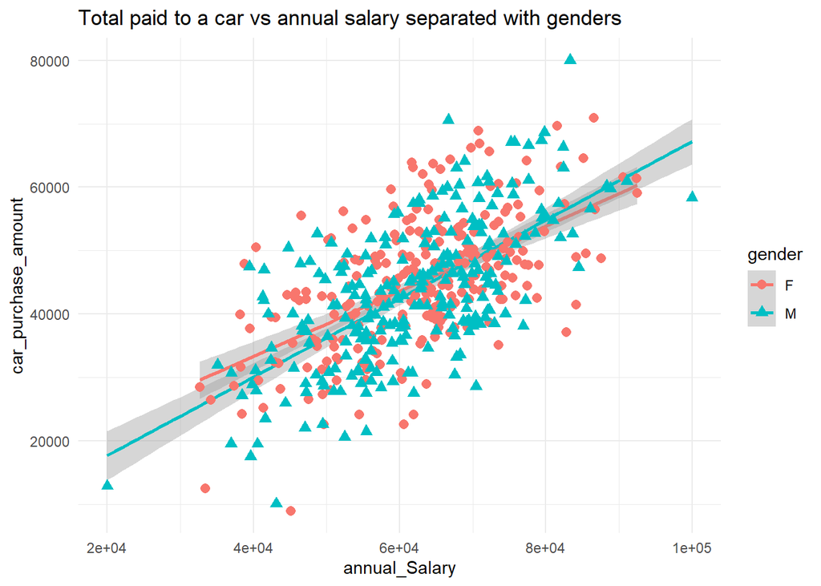

Creating a data frame which will store **annual Salary**.

```r
s <-  as.data.frame(65000)
colnames(s) <- "annual_Salary"
```

Calculating the correlation between **annual_Salary** and **car_purchase_amount**.

```r
cor(dfdata$car_purchase_amount,dfdata$annual_Salary)
```

```
## [1] 0.6178617
```

It has a moderate positive relationship

```r
model2 <- lm(car_purchase_amount ~ annual_Salary, data = dfdata)
summary(model2)
```

```
##
## Call:
## lm(formula = car_purchase_amount ~ annual_Salary, data = dfdata)
##
## Residuals:
##      Min       1Q   Median       3Q      Max
## -25521.4  -5823.1   -648.4   5955.0  23813.8
##
## Coefficients:
##                Estimate Std. Error t value Pr(>|t|)
## (Intercept)   8.875e+03  2.050e+03   4.328 1.82e-05 ***
## annual_Salary 5.687e-01  3.243e-02  17.536  < 2e-16 ***
## ---
## Signif. codes:  0 '***' 0.001 '**' 0.01 '*' 0.05 '.' 0.1 ' ' 1
##
## Residual standard error: 8479 on 498 degrees of freedom
## Multiple R-squared:  0.3818, Adjusted R-squared:  0.3805
## F-statistic: 307.5 on 1 and 498 DF,  p-value: < 2.2e-16
```

I can predict at with 65,000 annual Salary the **car_purchase_amount** will be $45843.69.

```r
predict(model2, newdata = s)
```

```
##        1
## 45843.69
```

### Net Worth

```
## # A tibble: 76 x 7
## # Groups:   age [43]
##      age gender country annual_Salary credit_card_debt net_worth car_purchase_~1
##    <int> <chr>    <dbl>         <dbl>            <dbl>     <dbl>           <dbl>
##  1    20 M           NA        70467.             100    494607.          28645.
##  2    22 M           NA        43132.           10917.   326743.          10092.
##  3    25 F           NA        45093.           11380.   158758.           9000
##  4    27 F           NA        55370.           10889.   606851.          29671.
##  5    28 F           NA        82843.           13102.   315775.          37162.
##  6    29 M           NA        62303.            8562.   444786.          30088.
##  7    30 M           NA        66763.            6484.   426726.          33134.
##  8    31 F           NA        41362.           10756.   615720.          25253.
##  9    32 F           NA        68672.            9266.   453192.          36479.
## 10    32 M           NA        44926.           12158.   572525.          26529.
## # ... with 66 more rows, and abbreviated variable name 1: car_purchase_amount
```

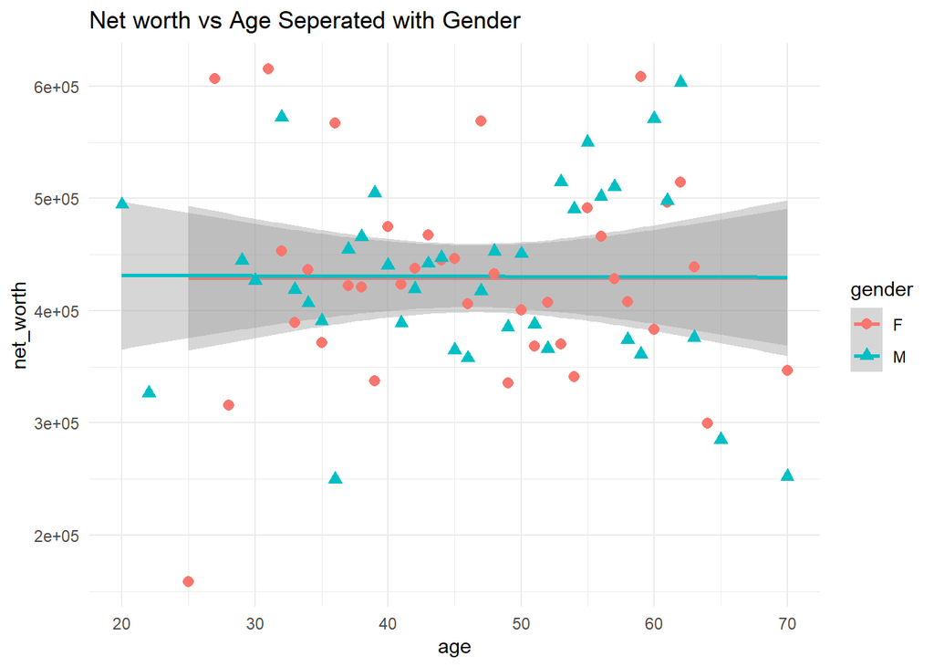

Classing People via their Net Worth and Net Worth for each Class.

```
##         country gender age annual_Salary credit_card_debt net_worth
## 1:     Bulgaria      F  42      62812.09         11609.38  238961.2
## 2:       Belize      F  41      66646.89          9572.96  530973.9
## 3:      Algeria      M  43      53798.55         11160.36  638467.2
## 4: Cook Islands      M  58      79370.04         14426.16  548599.1
## 5:       Brazil      M  57      59729.15          5358.71  560304.1
## 6:      Liberia      M  57      68499.85         14179.47  428485.4
##    car_purchase_amount class
## 1:            35321.46     4
## 2:            45115.53     2
## 3:            42925.71     2
## 4:            67422.36     2
## 5:            55915.46     2
## 6:            56612.00     3
```

```
##         1         2         3         4
## "#F8766D" "#4fba3a" "#619CFF" "#ebe046"
```

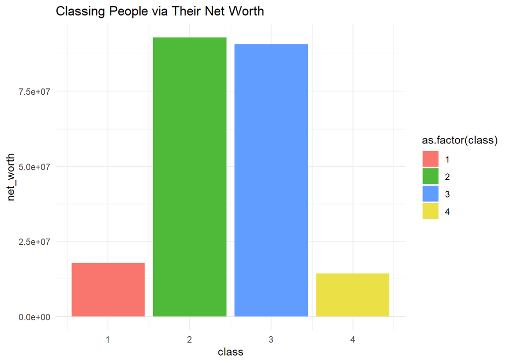

Calculating the correlation between **annual_Salary** + **net_Worth** and **car_purchase_amount**.

```r
dfsn <- subset (dfdata, select = -c(country,gender))
head(dfsn)
```

```
##    age annual_Salary credit_card_debt net_worth car_purchase_amount
## 1:  42      62812.09         11609.38  238961.2            35321.46
## 2:  41      66646.89          9572.96  530973.9            45115.53
## 3:  43      53798.55         11160.36  638467.2            42925.71
## 4:  58      79370.04         14426.16  548599.1            67422.36
## 5:  57      59729.15          5358.71  560304.1            55915.46
## 6:  57      68499.85         14179.47  428485.4            56612.00
```

Using cor( ) function and round( ) function we can round off the correlation between all variables of the dataset dfsn to two decimal places.

```r
round(cor(dfsn),2)
```

```
##                      age annual_Salary credit_card_debt net_worth
## age                 1.00          0.00             0.03      0.02
## annual_Salary       0.00          1.00             0.05      0.01
## credit_card_debt    0.03          0.05             1.00     -0.05
## net_worth           0.02          0.01            -0.05      1.00
## car_purchase_amount 0.63          0.62             0.03      0.49
##                     car_purchase_amount
## age                                0.63
## annual_Salary                      0.62
## credit_card_debt                   0.03
## net_worth                          0.49
## car_purchase_amount                1.00
```

It has a moderate positive relationship.

```r
model3 <- lm(car_purchase_amount ~ annual_Salary + net_worth, data = dfsn)
summary(model3)
```

```
##
## Call:
## lm(formula = car_purchase_amount ~ annual_Salary + net_worth,
##     data = dfsn)
##
## Residuals:
##      Min       1Q   Median       3Q      Max
## -22133.0  -4412.5   -106.5   4526.7  20059.9
##
## Coefficients:
##                 Estimate Std. Error t value Pr(>|t|)
## (Intercept)   -3.566e+03  1.781e+03  -2.002   0.0458 *
## annual_Salary  5.622e-01  2.573e-02  21.848   <2e-16 ***
## net_worth      2.977e-02  1.735e-03  17.155   <2e-16 ***
## ---
## Signif. codes:  0 '***' 0.001 '**' 0.01 '*' 0.05 '.' 0.1 ' ' 1
##
## Residual standard error: 6727 on 497 degrees of freedom
## Multiple R-squared:  0.6117, Adjusted R-squared:  0.6101
## F-statistic: 391.4 on 2 and 497 DF,  p-value: < 2.2e-16
```

I can predict at with 65,000 annual Salary and 500000 networth the **car_purchase_amount** will be $47865.01.

```r
predict(model3, newdata = sn)
```

```
##        1
## 47865.01
```

## Part 4 - Inference

The cases are car purchase amount and there are 500 cases in the data set.

```r
summary(dfdata)
```

```
##    country             gender               age        annual_Salary
##  Length:500         Length:500         Min.   :20.00   Min.   : 20000
##  Class :character   Class :character   1st Qu.:41.00   1st Qu.: 54392
##  Mode  :character   Mode  :character   Median :46.00   Median : 62916
##                                        Mean   :46.22   Mean   : 62127
##                                        3rd Qu.:52.00   3rd Qu.: 70118
##                                        Max.   :70.00   Max.   :100000
##  credit_card_debt   net_worth       car_purchase_amount
##  Min.   :  100    Min.   :  20000   Min.   : 9000
##  1st Qu.: 7398    1st Qu.: 299824   1st Qu.:37630
##  Median : 9655    Median : 426750   Median :43998
##  Mean   : 9608    Mean   : 431476   Mean   :44210
##  3rd Qu.:11799    3rd Qu.: 557325   3rd Qu.:51255
##  Max.   :20000    Max.   :1000000   Max.   :80000
```

Both sample sizes are bigger than 30, it is a random sample, and observation is independent. Therefore the conditions for inference should be satisfied.

```r
by(dfdata$car_purchase_amount, dfdata$gender, length)
```

```
## dfdata$gender: F
## [1] 247
## ------------------------------------------------------------
## dfdata$gender: M
## [1] 253
```

### Hypothesis Test

HO: The average car purchase amount of a people who has net worth more than average is the same as a people who has less than average. HA: The average car purchase amount of a people who has net worth more than average is different as a people who has less than average.

The average net worth is $431,476. Use **mutate** to add new column named **net_worth_average**, values with **above** and **below**.

```r
dfdata <- dfdata %>%
  mutate(net_worth_average = ifelse(dfdata$net_worth > 431476, "above", "below"))
head(dfdata)
```

```
##         country gender age annual_Salary credit_card_debt net_worth
## 1:     Bulgaria      F  42      62812.09         11609.38  238961.2
## 2:       Belize      F  41      66646.89          9572.96  530973.9
## 3:      Algeria      M  43      53798.55         11160.36  638467.2
## 4: Cook Islands      M  58      79370.04         14426.16  548599.1
## 5:       Brazil      M  57      59729.15          5358.71  560304.1
## 6:      Liberia      M  57      68499.85         14179.47  428485.4
##    car_purchase_amount net_worth_average
## 1:            35321.46             below
## 2:            45115.53             above
## 3:            42925.71             above
## 4:            67422.36             above
## 5:            55915.46             above
## 6:            56612.00             below
```

```r
# Sample size for each category
dfdata %>%
  group_by(net_worth_average) %>%
  summarise(freq = table(net_worth)) %>%
  summarise(n = sum(freq))
```

```
## # A tibble: 2 x 2
##   net_worth_average     n
##   <chr>             <int>
## 1 above               243
## 2 below               257
```

Calculate the standard deviation.

```r
dfdata %>%
  group_by(net_worth_average) %>%
  summarise(sd_car_purchase_amount = sd(car_purchase_amount, na.rm = TRUE))
```

```
## # A tibble: 2 x 2
##   net_worth_average sd_car_purchase_amount
##   <chr>                              <dbl>
## 1 above                             10175.
## 2 below                              9846.
```

Calculate the mean.

```r
dfdata %>%
  group_by(net_worth_average) %>%
  summarise(mean_car_purchase_amount = mean(car_purchase_amount, na.rm = TRUE))
```

```
## # A tibble: 2 x 2
##   net_worth_average mean_car_purchase_amount
##   <chr>                                <dbl>
## 1 above                               48334.
## 2 below                               40311.
```

```r
xnot3 <- 48334
nnot3 <- 243
snot3 <- 10175
x3 <- 40311
n3 <- 257
s3 <- 9846

z = 1.96

uci_not <- xnot3 + z*(snot3/sqrt(nnot3))
lci_not <- xnot3 - z*(snot3/sqrt(nnot3))
uci_not
```

```
## [1] 49613.34
```

```r
lci_not
```

```
## [1] 47054.66
```

```r
u_ci <- x3 + z*(s3/sqrt(n3))
l_ci <- x3 - z*(s3/sqrt(n3))

u_ci
```

```
## [1] 41514.79
```

```r
l_ci
```

```
## [1] 39107.21
```

With 95% confident that people whose **net_worth** is above average have an average **car_purchase_amount** between 47054.66 and 49613.34. Also, people whose **net_worth** is below average have an average **car_purchase_amount** between 39107.21 and 41514.79 with a 95% confident level. People with higher net worth spend more money purchasing cars.

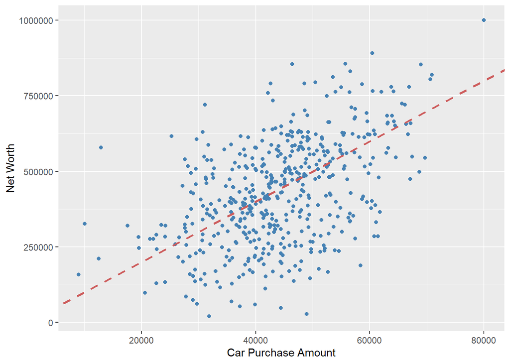

```r
# Total Paid to a Car vs Net Worth
dfdata %>%
  ggplot(aes(x = car_purchase_amount, y = net_worth)) +
  geom_point(color='steelBlue') +
  geom_abline(intercept = 50, slope = 10, linewidth = 1, color='indianred', linetype='dashed') +
  labs(
    x = 'Car Purchase Amount',
    y = 'Net Worth'
  )
```

## Part 5 - Conclusion

The purpose of data analysis is to extract useful information from data, make decisions based on data analysis, and derive insights. Before I start analyzing the data I had to think carefully about why I wanted to analyze the data and what kind of data they needed to analyze. This project’s data analysis process was completed with data collection, data cleaning, data analysis, and data visualization. I think age, annual salary, net worth, and car purchase amount are indicators that help predict the purchase price of a car. However, I don’t think credit card debt is a good indicator for predicting prices. This is because there are so many variables and the circumstances of each person’s credit card debt are so diverse. Consequently, through this data, I was able to find that middle-aged people with better financial status buy more expensive cars than the younger generation.